# Lesson 10 Introduction

ANTH 102-W1

Spring 2015

In our final lesson, we travel back across the Atlantic Ocean (or, Pacific, depending on where you begin) to the Western Hemisphere to investigate state-level societies that arose in Mesoamerica and the Andean region of South America.

One of the civilizations we will cover is the Maya, depicted in the movie [*Apocalypto*](http://www.imdb.com/title/tt0472043/). Though the movie takes certain liberties for entertainment value, some aspects of the film are supported by archaeological evidence. If you haven’t already seen the movie, it may be fun to watch it after this lesson so you can scream, “Hey! That’s not accurate.” (Just make sure you watch it alone, since any company probably would get tired of the high-brow critique.) While the film portrayed some things like human sacrifice, Classic and Post-classic Mayan culture is probably best known for its magnificent ruins that remain, such as the Temple of the Warriors (below) at Chichen Itza in Mexico.

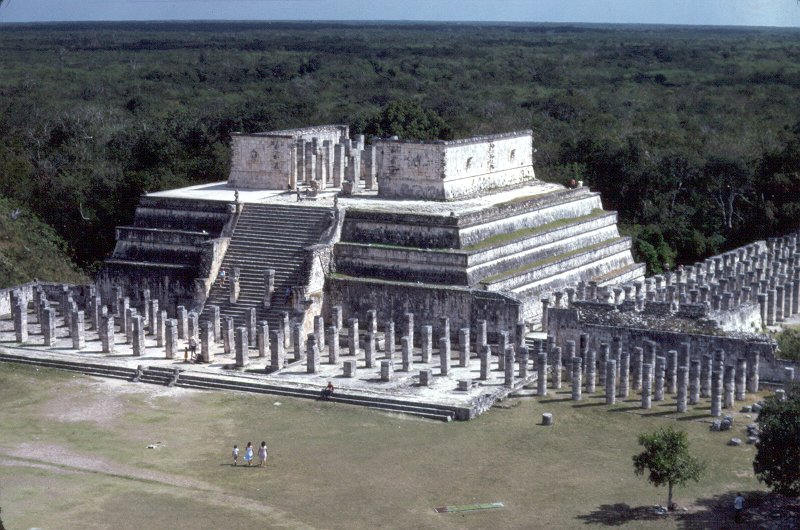

Temple de los Guerreros at the Late-/Post-classic Mayan capital of Chichen Itza, Mexico

### Objectives

By the end of this lesson, you should be able to do the following:

- Describe cultures of Mesoamerica and interpretations about prehistoric/historic developments there based on archaeological evidence.
- Discribe our models of major elements of Mayan culture and how that culture changed over time (i.e., development and collapse of “Classic” Mayan culture).
- Evaluate the archaeological evidence for social organization in the city-state of Teotihuacán.
- Understand the development and influence of the Aztec Empire.
- Describe the major cultures important to the development of social complexity in the Andes of South America (e.g., Chavín de Huántar, Moche, Wari…).
- Describe the basic political and economic characteristics of the Inca Empire.